# Environmental and Land Use Data

# 1 Setup

Load packages:

```r
package_list <- c(
  'tidyverse', 'terra', 'sf', 'landscapemetrics', "parallel", "DT", "corrplot",
  "FactoMineR", "factoextra", "broom"
  )

invisible(
  lapply(
    package_list,
    require,
    character.only = TRUE
  )
)
```

Source functions.

```r
invisible(
  lapply(
    list.files('functions/', full.names = TRUE),
    source)
  )
```

# 2 Loading Input Data

Get input file locations.

```r
# location of sample coordinate file
#sample_coordinate_location <- "input_data/00_sample_data/samples_coords.csv"

# location of sample files
sample_file_location <-
  "/mnt/data2/Project_Polli_agro/Operational/4_data_analysis/7_seldetection/environmental_data/input_data/00_sample_data/ALL_samples_metadata_complete.csv"
```

## 2.1 Sample Metadata input

Load and tidy sample coordinate data. This table contains data for all samples, even those not used in the SSF analysis.

```r
sample_metadata <- read.csv(sample_file_location)
```

Create a separate dataframe with only poll data.

```r
final_poll_metadata <- sample_metadata %>%
  select(poll, location, landscape_level_1, landscape_level_2, LAT, LONG) %>%
  distinct() %>%
  arrange(poll)

final_poll_metadata %>% datatable()
```

|  | poll | location | landscape_level_1 | landscape_level_2 | LAT | LONG |
| --- | --- | --- | --- | --- | --- | --- |
| 1 | poll001 | Alcobaça | SSF | SSF | 39.4980908 | -9.0390424 |
| 2 | poll002 | Alcobaça | SSF | SSF | 39.4843098 | -8.9934508 |
| 3 | poll003 | Alcobaça | SSF | SSF | 39.5044021 | -9.0390424 |
| 4 | poll004 | Serra_de_Aire_e_Candeeiros | LoA | LoA_Near | 39.4924514 | -8.9299633 |
| 5 | poll007 | Bombarral | SSF | SSF | 39.2527008 | -9.1696696 |
| 6 | poll008 | Bombarral | SSF | SSF | 39.2650447 | -9.1627322 |
| 7 | poll009 | Bombarral | SSF | SSF | 39.2633275 | -9.1703536 |
| 8 | poll010 | Turcifal | SSF | SSF | 39.0438174 | -9.2728438 |
| 9 | poll011 | Sintra | LoA | LoA_Near | 38.8016958 | -9.4844644 |
| 10 | poll013 | Foros_Vale_Figueira | LoA | LoA_Far | 39.140458 | -8.525554 |

[output cut: 67 more lines]

# 3 Land Use Analysis

## 3.1 Extract Landscape Metrics

### 3.1.1 Read and Tidy Land Use Data

Load land use data for Portugal. The merged raster was created from Sentinel rasters ‘29S’ and ‘29T’ with `gdal` in `merge_sentinel_rasters.sh`.

```r
sentinel_landuse_raster = rast(
  'input_data/01_raster_data/00_sentinel_land_use_rasters/sentinel_29S_29T_joined.tif',
  )
```

Add names to land use classes.

```r
# create dataframe with id - class key
land_use_classes <- data.frame(
  id = c(1, 2, 4, 5, 7, 8, 9, 10, 11),
  landuse = c(
    "Water", "Trees", "Flooded vegetation", "Crops", "Built Area",
    "Bare ground", "Snow/Ice", "Clouds", "Rangeland"
    )
  )

# add info to raster
levels(sentinel_landuse_raster) <- land_use_classes
```

Plot raster.

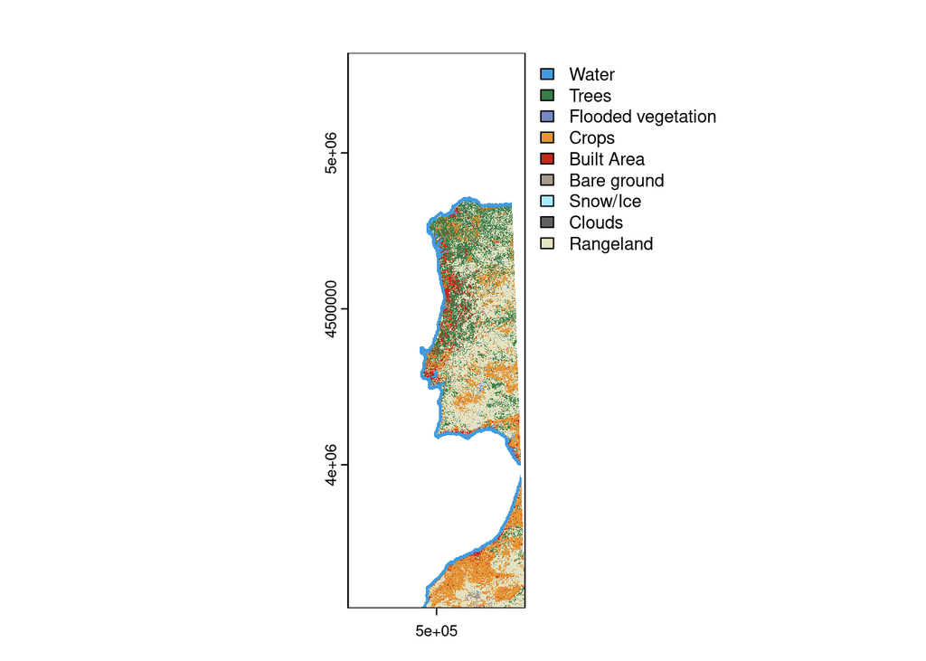

```r
plot(sentinel_landuse_raster)
```

### 3.1.2 Create Rasters for Each Sampling Landscape

Create a 1 km buffer around each geographical coordinate.

```r
# convert coordinates for each poll into a SpatVector object
poll_coords_sv = vect(
  final_poll_metadata,
  geom = c('LONG' ,'LAT'),
  crs = "EPSG:4326"
  )

# check if names were stored
poll_coords_sv$poll
```

```
 [1] "poll001" "poll002" "poll003" "poll004" "poll007" "poll008" "poll009"
 [8] "poll010" "poll011" "poll013" "poll015" "poll016" "poll017" "poll018"
[15] "poll019" "poll020" "poll021" "poll022" "poll023" "poll024" "poll025"
[22] "poll026" "poll027" "poll028" "poll029" "poll030" "poll031" "poll032"
[29] "poll052" "poll055" "poll058" "poll059" "poll060" "poll065" "poll066"
[36] "poll068" "poll070" "poll071" "poll072" "poll073" "poll074" "poll075"
[43] "poll076" "poll077" "poll079" "poll080" "poll082" "poll083" "poll084"
[50] "poll085" "poll086" "poll089" "poll091" "poll092" "poll094" "poll095"
[57] "poll096" "poll099" "poll100" "poll101" "poll102" "poll104" "poll105"
[64] "poll136" "poll500" "poll501" "poll502" "poll503" "poll505" "poll506"
[71] "poll507" "poll508" "poll509" "poll510" "poll511" "poll512" "poll513"
```

```r
# coordinate reference system must match that of the land use raster
# it is easier to re-project vector than re-project the raster
poll_coords_sv = project(x = poll_coords_sv, crs(sentinel_landuse_raster))

# create 1 km buffers around each point
poll_buffers_sv = buffer(poll_coords_sv, width = 1000)
```

```r
# create a raster for each poll and store them in a list
poll_landuse_raster_list <- lapply(
  1:nrow(poll_buffers_sv),
  \(x) crop_raster_with_buffer(poll_buffers_sv[x, 1], sentinel_landuse_raster)
  )

# set list entry names
names(poll_landuse_raster_list) <- poll_buffers_sv$poll
```

```r
for (poll in names(poll_landuse_raster_list)) {

  jpeg(filename = paste0("results/poll_landscape_buffers/", poll, ".jpg"))
  poll_landuse_raster_list[[poll]] %>%
    plot(
      main = poll,
      plg = list(title="Land Use Class"))
  dev.off()

}
```

### 3.1.3 Extract Landscape Metrics for Each Sampling Landscape

Check the input landscapes.

```r
check_landscape(poll_landuse_raster_list) %>% datatable()
```

|  | layer | crs | units | class | n_classes | OK |
| --- | --- | --- | --- | --- | --- | --- |
| poll001 | 1 | projected | m | integer | 4 | ✔ |
| poll002 | 2 | projected | m | integer | 4 | ✔ |
| poll003 | 3 | projected | m | integer | 4 | ✔ |
| poll004 | 4 | projected | m | integer | 6 | ✔ |
| poll007 | 5 | projected | m | integer | 5 | ✔ |
| poll008 | 6 | projected | m | integer | 4 | ✔ |
| poll009 | 7 | projected | m | integer | 4 | ✔ |
| poll010 | 8 | projected | m | integer | 3 | ✔ |
| poll011 | 9 | projected | m | integer | 5 | ✔ |
| poll013 | 10 | projected | m | integer | 5 | ✔ |

[output cut: 67 more lines]

Create list of `landscapemetrics` functions to use on our landscapes.

```r
landscapemetrics_function_list <- c(
  lsm_l_area_cv, lsm_l_area_mn, lsm_l_area_sd, lsm_l_cohesion, lsm_l_condent,
  lsm_l_contag, lsm_l_contig_cv, lsm_l_contig_mn, lsm_l_contig_sd, lsm_l_ed,
  lsm_l_ent, lsm_l_iji, lsm_l_joinent,
  lsm_l_lpi, lsm_l_np, lsm_l_pd, lsm_l_pr, lsm_l_prd, lsm_l_shdi, lsm_l_shei,
  lsm_l_sidi, lsm_l_siei, lsm_l_ta, lsm_l_te, lsm_c_ca
  )

# lsm_l_enn_cv, lsm_l_enn_mn, lsm_l_enn_sd,
```

Calculate metrics for each landscape.

```r
# apply calculate_landscape_metrics() to each raster
poll_landscapemetrics_df <- parallel::mclapply(
  poll_landuse_raster_list,
  \(x) calculate_landscape_metrics(x, landscapemetrics_function_list),
  mc.cores = 79
  ) %>%
  # bind list entries into a dataframe
  bind_rows()

write.csv(poll_landscapemetrics_df, "results/landscape_metrics/raw_landscape_metrics.csv")
```

```r
poll_landscapemetrics_df %>% datatable()
```

|  | layer | level | class | id | metric | value | poll |
| --- | --- | --- | --- | --- | --- | --- | --- |
| 1 | 1 | landscape |  |  | area_cv | 336.7117745490867 | poll001 |
| 2 | 1 | landscape |  |  | area_mn | 6.090384615384616 | poll001 |
| 3 | 1 | landscape |  |  | area_sd | 20.50704211532611 | poll001 |
| 4 | 1 | landscape |  |  | cohesion | 98.84898021309371 | poll001 |
| 5 | 1 | landscape |  |  | condent | 0.2476911425704968 | poll001 |
| 6 | 1 | landscape |  |  | contag | 50.37081867527407 | poll001 |
| 7 | 1 | landscape |  |  | contig_cv | 63.47480466739126 | poll001 |
| 8 | 1 | landscape |  |  | contig_mn | 0.5723940137792707 | poll001 |
| 9 | 1 | landscape |  |  | contig_sd | 0.3633259821742327 | poll001 |
| 10 | 1 | landscape |  |  | ed | 66.52983896431955 | poll001 |

[output cut: 2171 more lines]

# 4 Landuse Class Composition Analysis

## 4.1 Transform Data

Calculate the proportion of area occupied by each landscape type in each sampling location.

Because some landscapes include a lot of area covered by water, especially those close to the coast, it is necessary to calculate the proportions subtracting the area covered by water from the total area.

```r
# calculate the area occupied by each class in each sampling location
poll_landuse_class_area <- poll_landscapemetrics_df %>%
  filter(
    metric %in% c("ca", "ta")
    ) %>%
  left_join(
    final_poll_metadata
    ) %>%
  left_join(
    land_use_classes, by = join_by(class == id)
    ) %>%
  mutate(
    metric = case_when(
      metric == "ca" ~ paste0(metric, "_", landuse),
      .default = metric
      )
    ) %>%
  # sum polls belonging to each sampling location
  summarise(
    total_area = sum(value),
    .by = c(location, metric) # important
    ) %>%
  pivot_wider(
    names_from = metric,
    values_from = total_area,
    values_fill = 0
    ) %>%
  # join location metadata
  left_join(
    final_poll_metadata %>%
      select(location, landscape_level_1, landscape_level_2) %>%
      distinct(),
    "location"
    )

# transform class areas into class proportions in relation to total landscape area
poll_landuse_class_prop <- poll_landuse_class_area %>%
  mutate(
    across(
      starts_with("ca_"),
      \(x) x/ta
      )
    )

# transform class areas into class proportions in relation to total landscape
# area that is not water
poll_landuse_class_prop_nw <- poll_landuse_class_area %>%
  mutate(
    ta_minus_water = ta - ca_Water,
    across(
      starts_with("ca_"),
      \(x) x/ta_minus_water
      )
    ) %>%
  select(-ta, -ca_Water)

# write files
write_csv(poll_landuse_class_area, "results/landscape_metrics/poll_landuse_class_area.csv")
write_csv(poll_landuse_class_prop, "results/landscape_metrics/poll_landuse_class_propotion.csv")
write_csv(poll_landuse_class_prop_nw, "results/landscape_metrics/poll_landuse_class_propotion_no_water.csv")
```

|  | location | ca_Trees | ca_Crops | ca_Built Area | ca_Rangeland | ca_Bare ground | landscape_level_1 | landscape_level_2 | ta_minus_water |
| --- | --- | --- | --- | --- | --- | --- | --- | --- | --- |
| 1 | Alcobaça | 0.2275191447418304 | 0.324841408244244 | 0.4109516769024693 | 0.03517451411529811 | 0.001513255996158415 | SSF | SSF | 3165.36 |
| 2 | Serra_de_Aire_e_Candeeiros | 0.6793748520009472 | 0.004309732417712527 | 0.1880811429473518 | 0.1234667298129292 | 0.004767542821059278 | LoA | LoA_Near | 633.45 |
| 3 | Bombarral | 0.0203538239720477 | 0.4959744893126638 | 0.4759784885128237 | 0.007661625569622917 | 3.157263284185268e-05 | SSF | SSF | 950.19 |
| 4 | Turcifal | 0.09793228504154375 | 0.6662110837460644 | 0.2327487437639268 | 0.003107887448465001 | 0 | SSF | SSF | 2216.94 |
| 5 | Sintra | 0.6306039171129479 | 0.0003048336924366604 | 0.3122397655551784 | 0.0515653902910469 | 0.005286093348390271 | LoA | LoA_Near | 1443.41 |
| 6 | Foros_Vale_Figueira | 0.07118276627763805 | 0.1148037843469476 | 0.1953316565463099 | 0.6183450322553488 | 0.0003367605737558275 | LoA | LoA_Far | 950.23 |
| 7 | Odeceixe | 0.1511435657205842 | 0.1410001805380033 | 0.0842399825163197 | 0.6148411740671412 | 0.00877509715795175 | LoA | LoA_Far | 2104.82 |
| 8 | Nazare | 0.3807439375256885 | 0.09665707631182355 | 0.1897451705713111 | 0.2953349773941635 | 0.03751883819701329 | LoA | LoA_Near | 1459.8 |
| 9 | Arruda_dos_Vinhos | 0.1297618859517452 | 0.6206568282007932 | 0.2054740950244119 | 0.03833604575834663 | 0.005771145064703186 | SSF | SSF | 2531.56 |
| 10 | Assafora | 0.05780560933164666 | 0.04966348203490283 | 0.2291816637895487 | 0.6626783055988483 | 0.0006709392450535704 | LoA | LoA_Near | 1430.83 |

[output cut: 5 more lines]

## 4.2 Plot prop of each class

Plot proportion of each class (excluding Clouds, Snow and Flooded Vegetation) for the two types of landscape, small-scale farming and low agricultural.

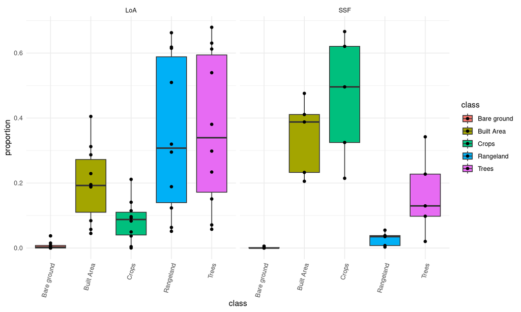

```r
poll_landuse_class_prop_nw %>%
  pivot_longer(
    starts_with("ca_"),
    names_to = "class",
    values_to = "proportion"
  ) %>%
  mutate(
    class = str_remove(class, "ca_")
  ) %>%
  # filter(
  #   proportion > 0#,
  #   # !class %in% c("Clouds", "Snow/Ice", "Flooded vegetation")
  # ) %>%
  ggplot(
    aes(x = class,
        y = proportion,
        fill = class)
  ) +
  geom_boxplot() +
  geom_point() +
  facet_wrap(~landscape_level_1) +
  theme_minimal() +
  theme(axis.text.x = element_text(angle = 75, hjust = 1))
```

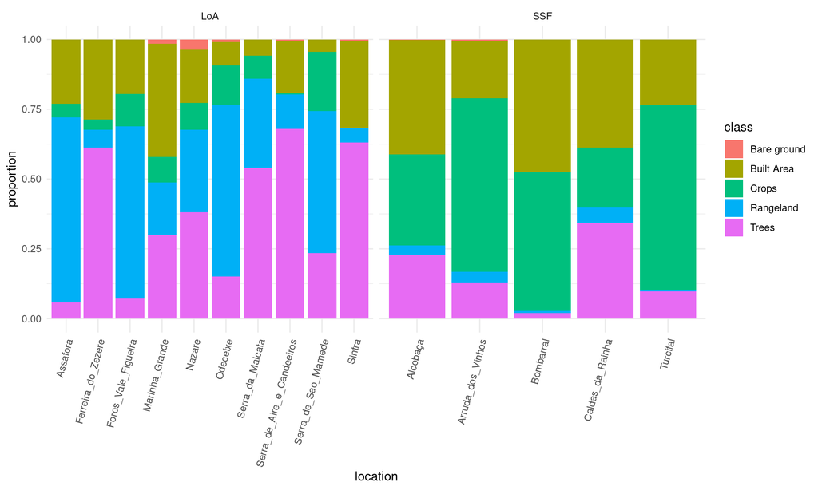

```r
poll_landuse_class_prop_nw %>%
  pivot_longer(
    starts_with("ca_"),
    names_to = "class",
    values_to = "proportion"
  ) %>%
  mutate(
    class = str_remove(class, "ca_")
  ) %>%
  # filter(
  #   proportion > 0#,
  #   # !class %in% c("Clouds", "Snow/Ice", "Flooded vegetation")
  # ) %>%
  ggplot(
    aes(x = location,
        y = proportion,
        fill = class)
  ) +
  geom_bar(stat = "identity",position = position_stack()) +
  facet_wrap(~landscape_level_1, nrow = 1, scales = "free_x") +
  theme_minimal() +
  theme(axis.text.x = element_text(angle = 75, hjust = 1))
```

## 4.3 Statistical Tests

Tidy data by removing unwanted classes such as Clouds, Snow/Ice and Flooded Vegetation.

```r
# poll_landuse_class_prop_reduced <- poll_landuse_class_prop_nw %>%
#   select(
#     -ta_minus_water,
#     -paste0("ca_", c("Clouds", "Snow/Ice", "Flooded vegetation")),
#     -lat,
#     -long
#   ) %>%
#   column_to_rownames("poll")
```

Test both types of landscapes for normality in terms of class proportions.

```r
# poll_landuse_class_prop_list <- lapply(
#   c("SSF", "LoA"),
#   \(x) poll_landuse_class_prop_reduced %>%
#     filter(landscape == x) %>%
#     select(-landscape) %>%
#     as.list()
#   )
#
#
#
# ssf_shapiro <- apply(
#   poll_landuse_class_prop_reduced %>% filter(landscape == "SSF") %>% select(-landscape),
#   2,
#   shapiro.test
#   )
#
# loa_shapiro <- apply(
#   poll_landuse_class_prop_reduced %>% filter(landscape == "LoA") %>% select(-landscape),
#   2,
#   shapiro.test
#   )
```

Run Wilcoxon Rank Sum to test if the proportion of each landuse class is significantly different between SSF and LoA environments.

```r
# create a list with class proportion vectors for each environment
# poll_landuse_class_prop_list <- lapply(
#   c("SSF", "LoA"),
#   \(x) poll_landuse_class_prop_reduced %>%
#     filter(landscape == x) %>%
#     select(-landscape) %>%
#     as.list()
#   )
#
# names(poll_landuse_class_prop_list) <- c("SSF", "LoA")
#
# # run a wilcoxon test between environments for each of the landscape classes
# wilcox_test_results <- lapply(
#   colnames(poll_landuse_class_prop_reduced) %>% str_subset("ca_"),
#   \(x) wilcox.test(
#     poll_landuse_class_list[["SSF"]][[x]],
#     poll_landuse_class_list[["LoA"]][[x]]
#     )
#   )
#
# names(wilcox_test_results) <- colnames(poll_landuse_class_prop_reduced) %>%
#   str_subset("ca_")
#
# # run a wilcoxon test between environments for each of the landscape classes
# # wilcox_coin_test_results <- lapply(
# #   colnames(poll_landuse_class_prop_reduced) %>% str_subset("ca_"),
# #   \(x) coin::wilcox_test(
# #     poll_landuse_class_list[["SSF"]][[x]] ~ poll_landuse_class_list[["LoA"]][[x]],
# #     ties.method = "mid-rank"
# #     )
# #   )
#
# # names(wilcox_test_results) <- colnames(poll_landuse_class_prop_reduced) %>%
# #   str_subset("ca_")
#
# # display results
# lapply(
#   wilcox_test_results,
#   broom::tidy
#   ) %>%
#   bind_rows(.id = "class")
```

## 4.4 Correlation Between Land Use Classes

```r
# calculate Pearson correlation
poll_landuse_class_correlation <- cor(
  poll_landuse_class_prop_nw %>%
    select(-ta_minus_water, -landscape_level_1, -landscape_level_2) %>%
    column_to_rownames("location")
  )
```

Plot correlation matrix.

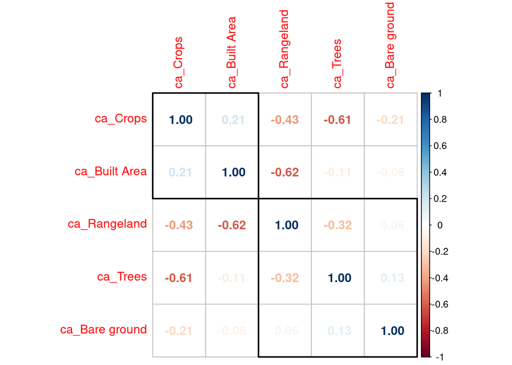

```r
corrplot(
  poll_landuse_class_correlation,
  method = "number",
  order = "hclust",
  addrect = 2
  )
```

**This shows that:**

- Proportion of Rangeland is negatively correlated to the proportion of Crops, Trees, and Built Area;
- Proportion of Trees is negatively correlated to the proportion of Crops.

## 4.5 Principal Components Analysis

Run PCA.

```r
poll_landuse_class_pca <- PCA(
  poll_landuse_class_prop_nw %>%
    select(-ta_minus_water) %>%
    column_to_rownames("location"),
  scale.unit = TRUE,
  quali.sup = 6:7,
  graph = FALSE
  )
```

Check variance.

```r
poll_landuse_class_pca$eig %>% datatable()
```

|  | eigenvalue | percentage of variance | cumulative percentage of variance |
| --- | --- | --- | --- |
| comp 1 | 1.950067557608364 | 39.00135115216727 | 39.00135115216727 |
| comp 2 | 1.515645249142956 | 30.31290498285912 | 69.3142561350264 |
| comp 3 | 0.9250063830413933 | 18.50012766082786 | 87.81438379585425 |
| comp 4 | 0.6092808102072872 | 12.18561620414574 | 100 |
| comp 5 | 2.142611768535634e-31 | 4.285223537071268e-30 | 100 |

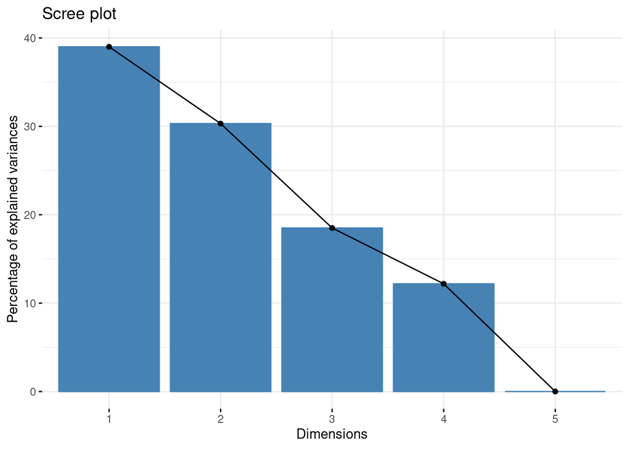

```r
fviz_screeplot(poll_landuse_class_pca, ncp=10)
```

**The first 3 dimensions together explain almost 90% of variation**.

Check variable contribution to each of the three dimentions.

```r
poll_landuse_class_pca$var$cos2 %>% datatable()
```

|  | Dim.1 | Dim.2 | Dim.3 | Dim.4 | Dim.5 |
| --- | --- | --- | --- | --- | --- |
| ca_Trees | 0.1672478108263077 | 0.7129985477618562 | 0.06815793508748369 | 0.05159570632435172 | 1.310404764330202e-62 |
| ca_Crops | 0.6625209576423473 | 0.1576344449000325 | 0.01674260108546568 | 0.1631019963721562 | 1.241608480998241e-62 |
| ca_Built Area | 0.5029541008382674 | 0.1658344795594721 | 0.01743536245658124 | 0.3137760571456787 | 4.536870378853172e-63 |
| ca_Rangeland | 0.511946536403903 | 0.4158335336173452 | 0.000250039028828946 | 0.07196989094992293 | 1.582529397906858e-62 |
| ca_Bare ground | 0.1053981518975384 | 0.06334424330424963 | 0.822420445383033 | 0.008837159415177731 | 2.555509546779255e-65 |

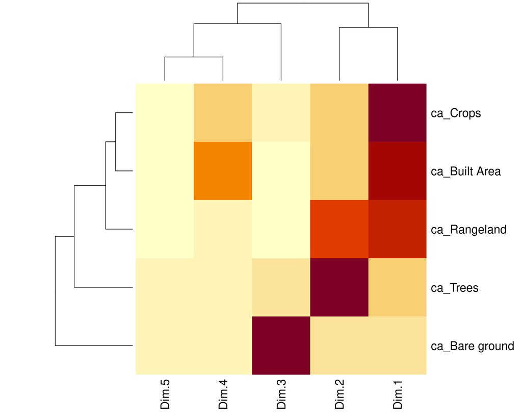

```r
poll_landuse_class_pca$var$cos2 %>% heatmap()
```

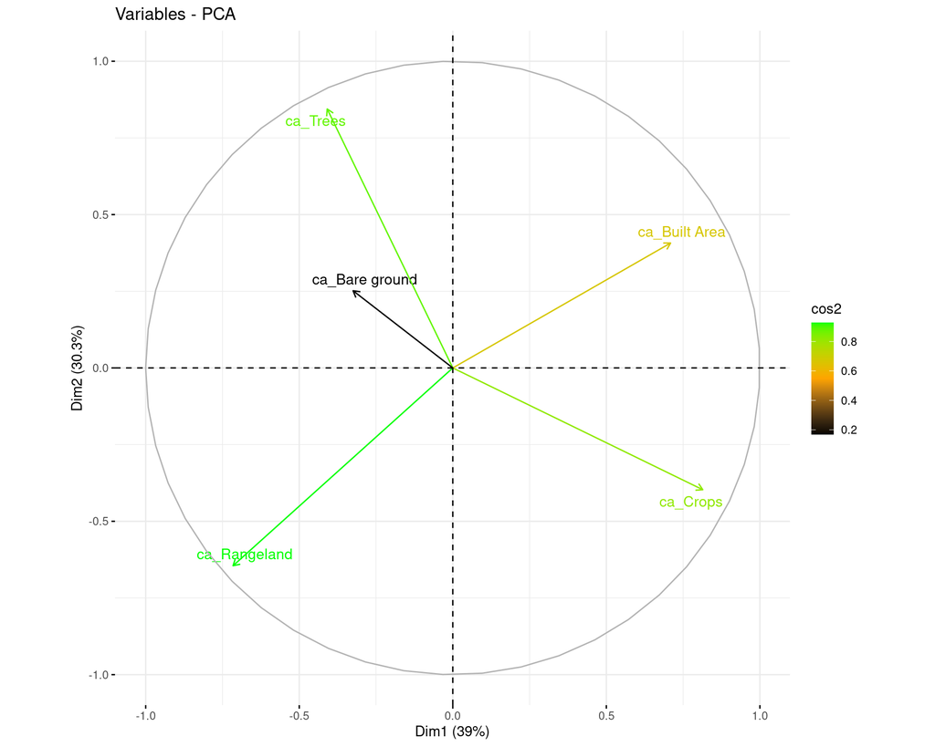

```r
fviz_pca_var(axes = c(1,2),
  poll_landuse_class_pca,
  col.var = "cos2",
  gradient.cols = c("black", "orange", "green"),
  repel = TRUE
  )
```

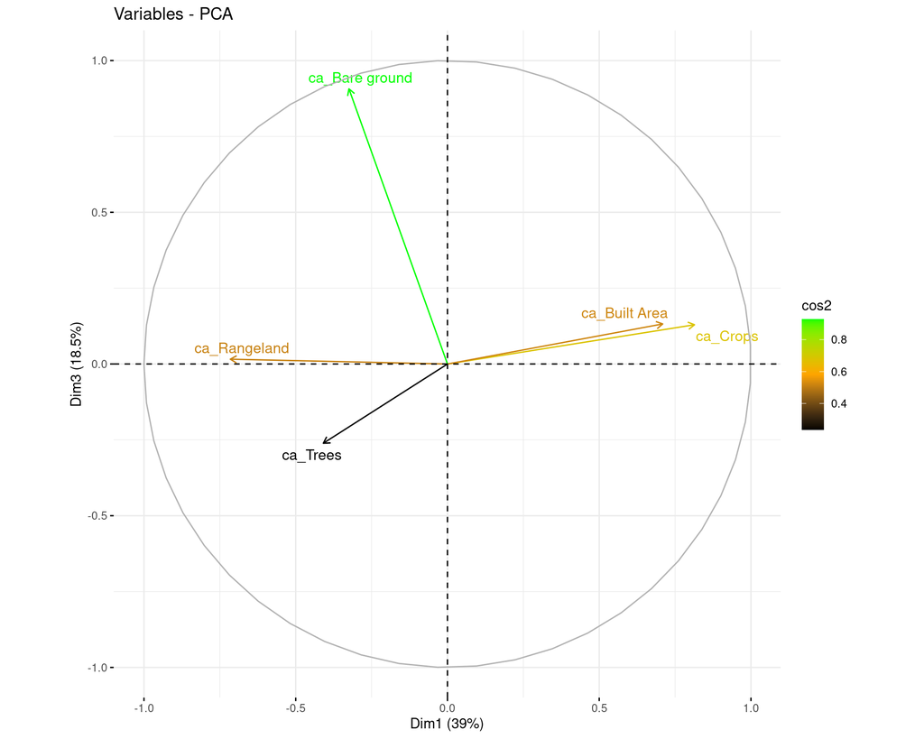

```r
fviz_pca_var(axes = c(1,3),
  poll_landuse_class_pca,
  col.var = "cos2",
  gradient.cols = c("black", "orange", "green"),
  repel = TRUE
  )
```

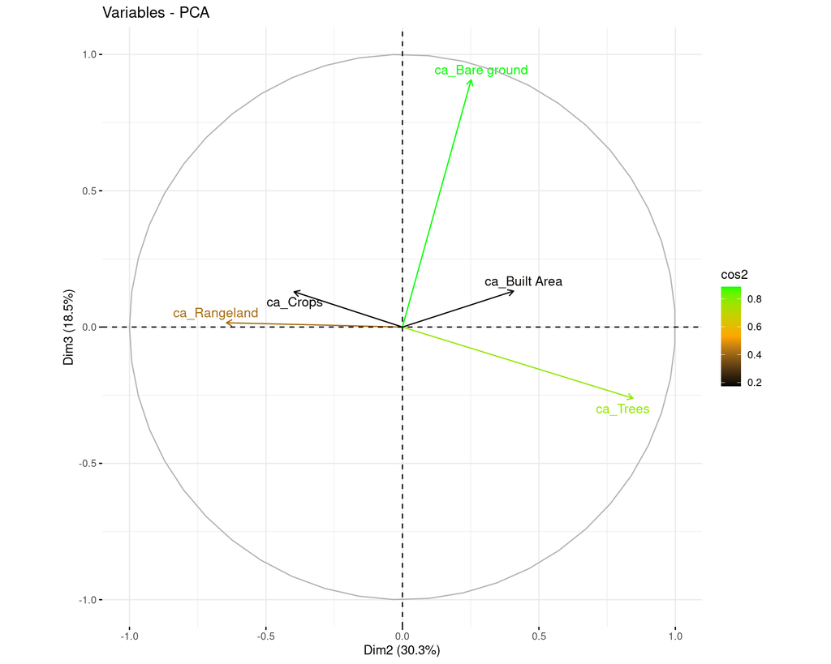

```r
fviz_pca_var(axes = c(2,3),
  poll_landuse_class_pca,
  col.var = "cos2",
  gradient.cols = c("black", "orange", "green"),
  repel = TRUE
  )
```

Dim1: - Most influenced by **proportion of crops, rangeland and built area**;

Dim2: - Most influenced by **proportion of trees and rangeland**;

Dim3: - Most influenced by **proportion of bare ground**;

Check samples.

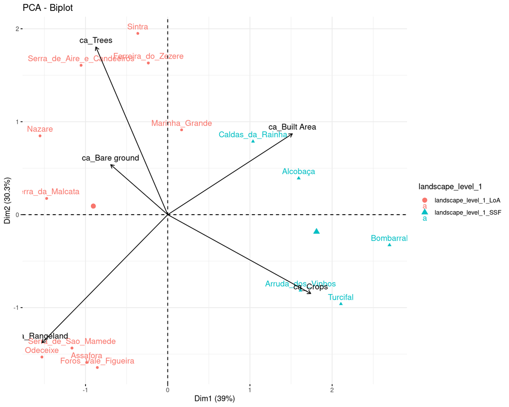

```r
fviz_pca_biplot(
  axes = c(1,2),
  poll_landuse_class_pca,
  label = "all",
  col.var = "black",
  habillage = 6
  )
```

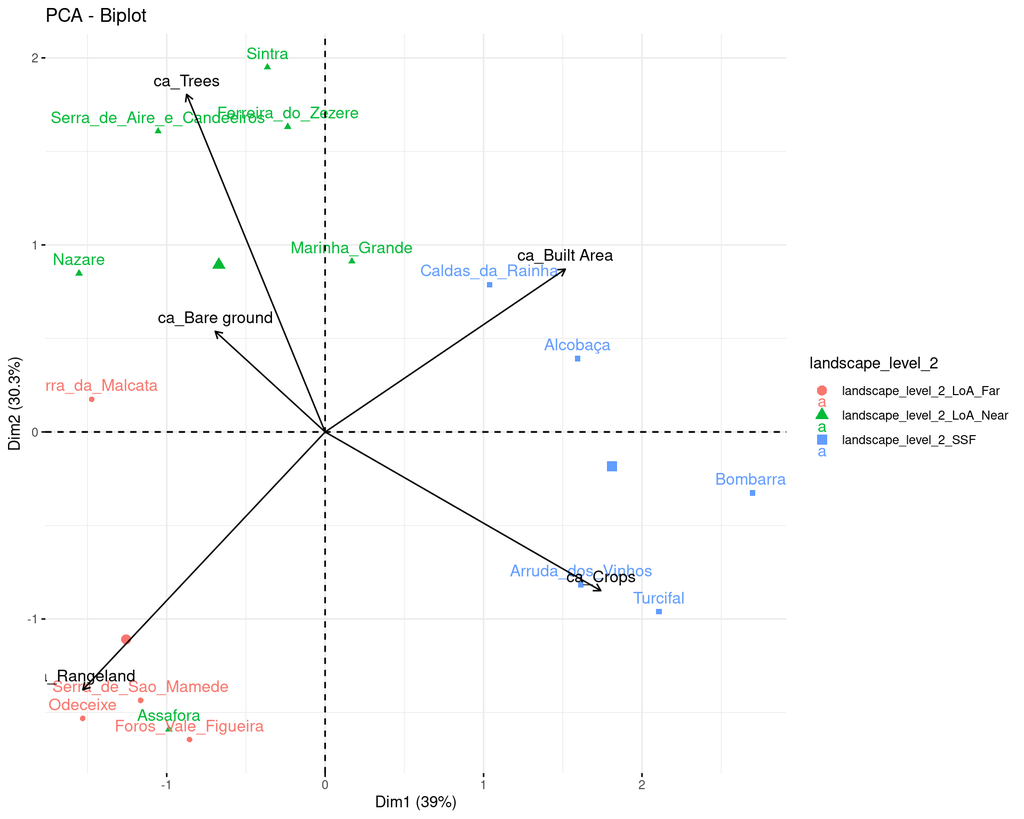

```r
fviz_pca_biplot(
  axes = c(1,2),
  poll_landuse_class_pca,
  label = "all",
  col.var = "black",
  habillage = 7
  )
```

```r
ggsave(filename = "results/landscape_metrics/PCA_SSF_LoA_class_composition.pdf", width = 10, height = 8)
```

Dim1 separates SSF (more built area and crops) from LoA (more rangeland). Dim2 separates landscapes based on proportion of rangeland and trees. Dim3 separates landscapes based on proportion of bare ground.

# 5 Landscape Metrics Analysis

## 5.1 Transform Data

Poll026 (Arruda) and poll052 (São Mamede) have less than 3 landuse classes and several metrics cannot be calculated, returning NAs. Because of this, NAs are ignored when calculating the median values for each sampling location.

```r
# calculate the median and mean of each metric in each location
poll_landuse_metrics_summary <- poll_landscapemetrics_df %>%
  filter(
    !metric %in% c("ca", "ta")
    ) %>%
  left_join(
    final_poll_metadata
    ) %>%
  left_join(
    land_use_classes, by = join_by(class == id)
    ) %>%
  # calculate median, mean, and standard deviation
  summarise(
    median = median(value, na.rm = TRUE),
    mean = mean(value, na.rm= TRUE),
    sd = sd(value, na.rm = TRUE),
    .by = c(location, metric)
    )

poll_landuse_metrics_median <- poll_landuse_metrics_summary %>%
  select(location, metric, median) %>%
  pivot_wider(
    names_from = metric,
    values_from = median,
    values_fill = 0
    ) %>%
  # join location metadata
  left_join(
    final_poll_metadata %>%
      select(location, landscape_level_1, landscape_level_2) %>%
      distinct(),
    "location"
    )

write_csv(poll_landuse_metrics_summary, "results/landscape_metrics/poll_landuse_metrics_mean_median_sd.csv")
write.csv(poll_landuse_metrics_median, "results/landscape_metrics/poll_landuse_metrics_median.csv")
```

```r
datatable(poll_landuse_metrics_median)
```

|  | location | area_cv | area_mn | area_sd | cohesion | condent | contag | contig_cv | contig_mn | contig_sd | ed | ent | iji | joinent | lpi | np | pd | pr | prd | shdi | shei | sidi | siei | te | landscape_level_1 | landscape_level_2 |
| --- | --- | --- | --- | --- | --- | --- | --- | --- | --- | --- | --- | --- | --- | --- | --- | --- | --- | --- | --- | --- | --- | --- | --- | --- | --- | --- |
| 1 | Alcobaça | 326.5491350913551 | 6.213161538461539 | 21.39258663354562 | 98.89749672413379 | 0.2646290706558446 | 54.81873458391603 | 63.65747455641281 | 0.5626689489356314 | 0.3502681105423758 | 74.54613692288216 | 1.511487001681359 | 76.27571819973107 | 1.807250616643359 | 40.13758538228915 | 51 | 16.10099628905097 | 4 | 1.263044885772447 | 1.049579963118893 | 0.7571119039040242 | 0.6052499505426732 | 0.8069999340568976 | 23610 | SSF | SSF |
| 2 | Serra_de_Aire_e_Candeeiros | 407.7032167321458 | 8.701675824175824 | 34.29341405113676 | 99.2777341016041 | 0.2155743073386615 | 67.78906310439481 | 53.82325205480558 | 0.5904535506415651 | 0.3102594782849029 | 58.91012873588858 | 1.24230759746667 | 60.02940743341187 | 1.457881904805331 | 63.56629643344884 | 40 | 12.62789702155918 | 5 | 1.578502078274024 | 0.8615908816674206 | 0.5503646138359205 | 0.4821539265887455 | 0.6106511349386252 | 18660 | LoA | LoA_Near |
| 3 | Bombarral | 271.4738000740434 | 16.67105263157895 | 50.57556895379429 | 99.43631161719706 | 0.1386888893284852 | 69.80316033440947 | 42.52197313445784 | 0.6544003228282403 | 0.2783969027402986 | 34.63736541315399 | 1.091724105971952 | 74.99292037181291 | 1.233608322783775 | 58.51725553345332 | 19 | 5.998421468034728 | 4 | 1.262985065201604 | 0.7575202685278435 | 0.5464353673889979 | 0.4923382137744242 | 0.6154227672180302 | 10970 | SSF | SSF |
| 4 | Turcifal | 305.099631941519 | 17.59944444444444 | 42.55218603390119 | 99.39133472844807 | 0.1831562312797346 | 61.41014533414631 | 40.17125731546047 | 0.6936356533517131 | 0.2786421631396921 | 50.98658247829518 | 1.242846804273849 | 54.08781280686631 | 1.422969435703605 | 60.31640773020083 | 18 | 5.681997537801067 | 4 | 1.26270597891281 | 0.8607246134202031 | 0.6721685033524494 | 0.5257046593436876 | 0.7236418575745125 | 16150 | SSF | SSF |
| 5 | Sintra | 281.3080956973829 | 17.59222222222222 | 47.00710053442559 | 99.4982660234136 | 0.1519717445821829 | 68.56820207876797 | 58.53383950149279 | 0.5986372565240132 | 0.3504053709299056 | 38.54653365323905 | 1.282074566117977 | 59.58563305844141 | 1.445043071883028 | 56.67382245232984 | 18 | 5.684330196425187 | 4 | 1.262785705265816 | 0.8901355322285313 | 0.5727921122092524 | 0.5327301808063876 | 0.6846751352349303 | 12210 | LoA | LoA_Near |
| 6 | Foros_Vale_Figueira | 273.8412577214468 | 13.77173913043478 | 38.76939803647552 | 99.26412933579635 | 0.1334613555832329 | 60.55722867881822 | 78.37094326439097 | 0.517596981842736 | 0.3842729611753378 | 33.3385951065509 | 1.444249497264039 | 75.90496564905116 | 1.577710852847272 | 50.24782951854775 | 23 | 7.261247040252565 | 4 | 1.263024944742658 | 1.000573101059102 | 0.7217609254724292 | 0.5850947501664809 | 0.7801263335553079 | 10560 | LoA | LoA_Far |
| 7 | Odeceixe | 327.0554962705348 | 9.597575757575758 | 38.79128114203877 | 99.2110369857574 | 0.2376521534277105 | 68.27600735356437 | 66.46780911155236 | 0.5228848616042949 | 0.3642028804150621 | 67.66228845668097 | 1.235564442727469 | 53.66188392916042 | 1.47321659615518 | 55.03946952952321 | 33 | 10.41929780247537 | 5 | 1.578681485223541 | 0.8550379157983438 | 0.5312649274585508 | 0.4271705781813475 | 0.5339632227266844 | 21430 | LoA | LoA_Far |
| 8 | Nazare | 261.6932622227504 | 9.596363636363636 | 23.09365736309519 | 98.83980015537679 | 0.2048236666182137 | 55.75568922736444 | 56.77264710158671 | 0.6170488004266438 | 0.3386650003631397 | 53.70843989769821 | 2.009325758804383 | 69.7575032371722 | 2.215001761629158 | 35.83291235160394 | 33 | 10.42061386888973 | 6 | 1.894357970511161 | 1.392658395730303 | 0.7809254810319906 | 0.7032185714702246 | 0.8854817690701973 | 17010 | LoA | LoA_Near |
| 9 | Arruda_dos_Vinhos | 302.868146753219 | 16.66921052631579 | 49.2136936824548 | 99.52812728339637 | 0.1655349985873805 | 74.8714948677984 | 60.16363607583745 | 0.5913243624328262 | 0.3342862768223682 | 46.36358448293193 | 0.8685230628971641 | 45.90790687022617 | 1.025392670864212 | 70.17705361476774 | 19 | 5.999084363739819 | 4.5 | 1.420748541889911 | 0.6025460309572545 | 0.4146486523897754 | 0.4070808112912476 | 0.5260760025468654 | 14685 | SSF | SSF |
| 10 | Assafora | 436.5959171239354 | 7.724634146341463 | 34.28634672035753 | 99.26286881713516 | 0.2186181304850359 | 67.6638969827837 | 67.76632332774696 | 0.5161439059857118 | 0.3490601915916347 | 60.33339647660542 | 1.478560393435173 | 62.86130062605084 | 1.671752274379208 | 56.41300915693085 | 41 | 12.94559691831644 | 5 | 1.578581802108985 | 1.025606586855182 | 0.5724019347848318 | 0.5675890869779316 | 0.681106904373518 | 19110 | LoA | LoA_Near |

[output cut: 5 more lines]

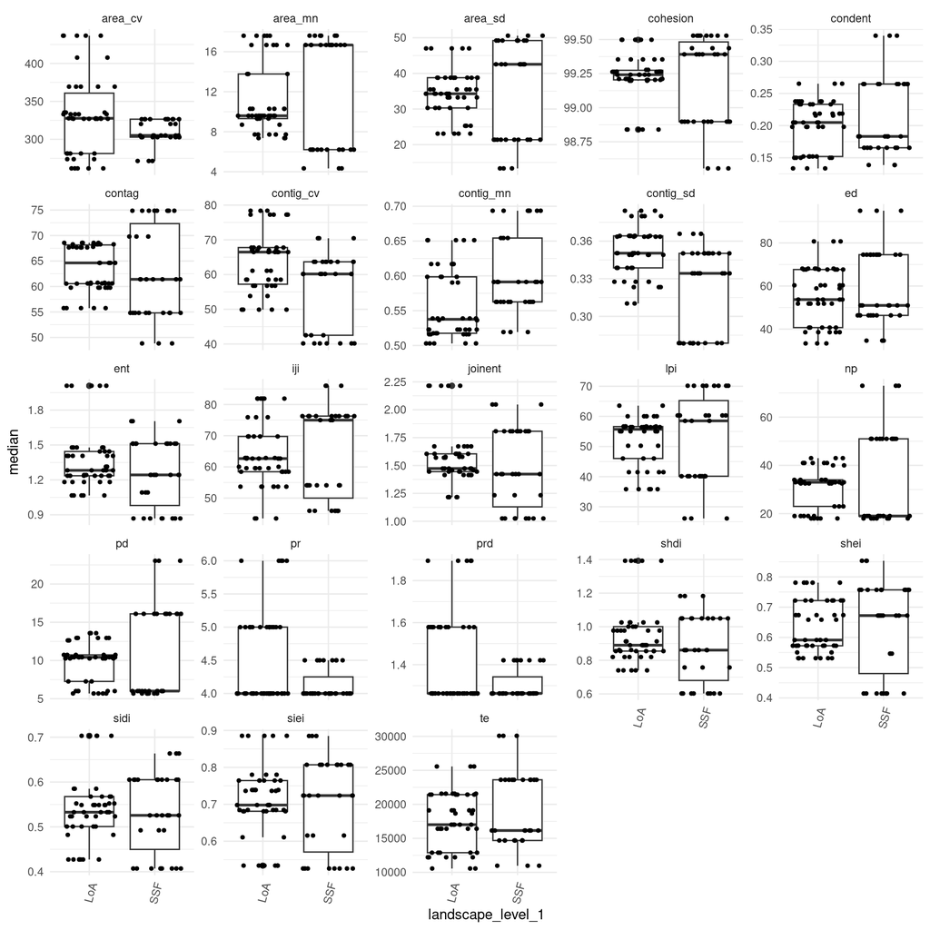

```r
poll_landuse_metrics_summary  %>%
  left_join(
    final_poll_metadata
    ) %>%
  ggplot(
    aes(
      x = landscape_level_1,
      y = median,
      #fill = metric
      )
  ) +
  geom_boxplot() +
  geom_point(position = position_jitter(), size= 1) +
  facet_wrap(
    ~metric, scales = "free_y") +
  theme_minimal() +
  theme(axis.text.x = element_text(angle = 75, hjust = 1))
```

## 5.3 Correlation Between LandscapeMetrics

```r
# calculate Pearson correlation
poll_landuse_metrics_correlation <- cor(
  poll_landuse_metrics_median %>%
    select(-landscape_level_1, -landscape_level_2) %>%
    column_to_rownames("location") %>%
    scale(),
  method = "pearson"
  )
```

Plot correlation matrix.

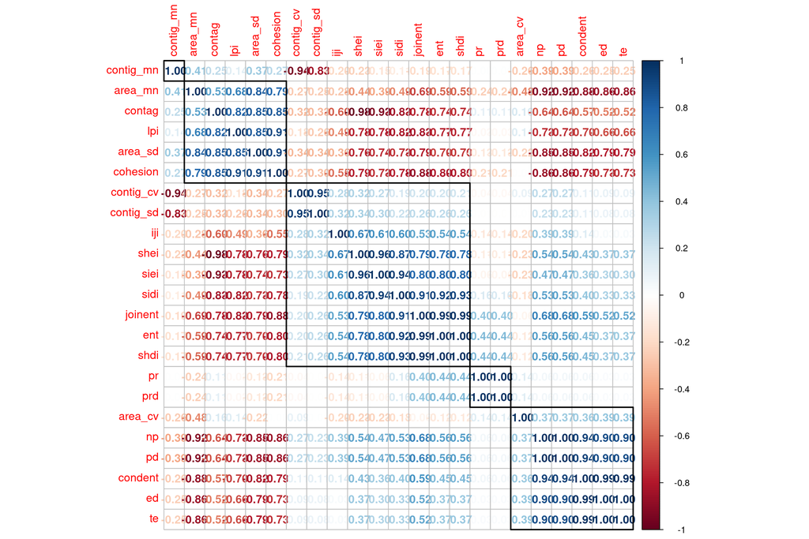

```r
corrplot(
  poll_landuse_metrics_correlation,
  method = "number",
  order = "hclust",
  addrect = 5
  )
```

Group 2:

- Standard Deviation and Coefficient of Variation (*contig_cv* and *contig_sv*) are strongly positively correlated to each other, and strongly negatively correlated to the mean Contiguity.

Group 3:

**LANDSCAPE FRAGMENTATION AND CONFIGURATION**

Edge Density (*ed*), Total Edge (*te*), Number of Patches (*np*), Patch Density (*pd*), and Conditional Entropy (*condent*) are all strongly positively correlated. They tend to increase with fragmentation.

Mean and Standard Deviation of patch area is strongly and negatively correlated to the above metrics. They tend to decrease with fragmentation.

Kept Number of Patches (*np*).

## 5.4 Principal Components Analysis

Run PCA.

```r
poll_landuse_metrics_pca <- PCA(
 poll_landuse_metrics_median %>%
    column_to_rownames("location"),
  scale.unit = TRUE,
  quali.sup = 24:25,
  graph = FALSE
  )
```

Check variance.

```r
poll_landuse_metrics_pca$eig %>% datatable()
```

|  | eigenvalue | percentage of variance | cumulative percentage of variance |
| --- | --- | --- | --- |
| comp 1 | 12.37161888852699 | 53.78964734142176 | 53.78964734142176 |
| comp 2 | 3.559560187701991 | 15.47634864218259 | 69.26599598360434 |
| comp 3 | 2.762825066470579 | 12.01228289769818 | 81.27827888130253 |
| comp 4 | 2.387870992328568 | 10.38204779273292 | 91.66032667403545 |
| comp 5 | 0.6986474000780911 | 3.037597391643877 | 94.69792406567932 |
| comp 6 | 0.5368562997089348 | 2.334157824821458 | 97.03208189050078 |
| comp 7 | 0.2384374047544084 | 1.036684368497429 | 98.06876625899821 |
| comp 8 | 0.1917655304898251 | 0.8337631760427187 | 98.90252943504093 |
| comp 9 | 0.10758156043439 | 0.4677459149321307 | 99.37027534997306 |
| comp 10 | 0.08173582921491834 | 0.3553731704996453 | 99.7256485204727 |

[output cut: 4 more lines]

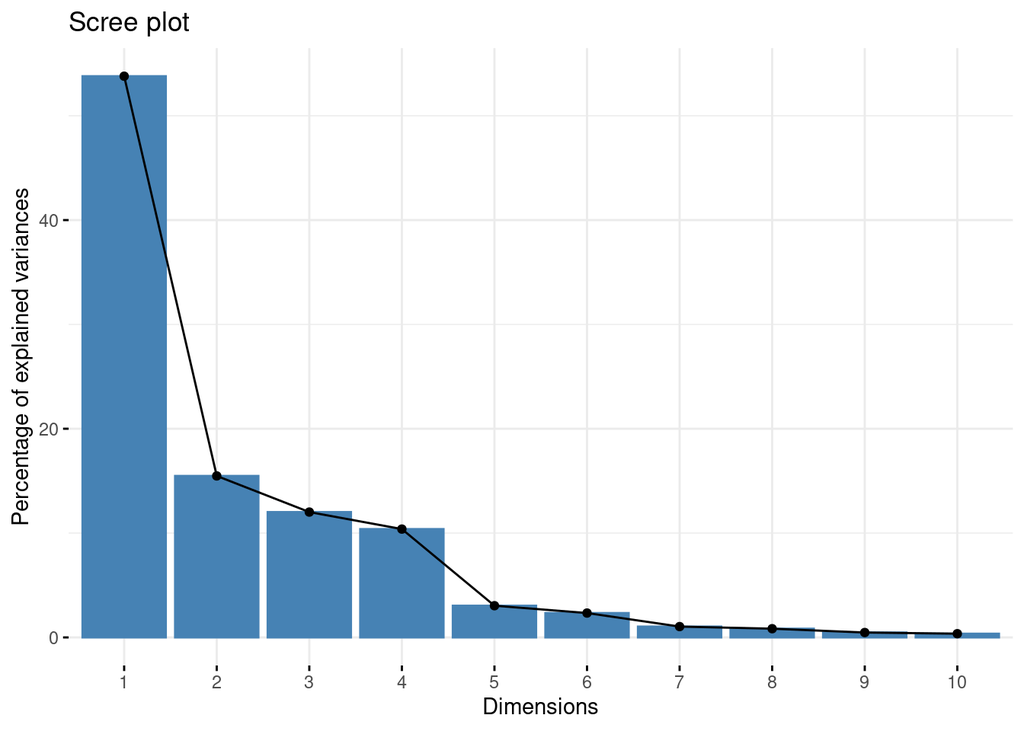

```r
fviz_screeplot(poll_landuse_metrics_pca, ncp=10)
```

**The first 4 dimensions together explain almost 90% of variation**.

Check variable contribution to each of the three dimensions.

```r
poll_landuse_metrics_pca$var$cos2 %>% datatable()
```

|  | Dim.1 | Dim.2 | Dim.3 | Dim.4 | Dim.5 |
| --- | --- | --- | --- | --- | --- |
| area_cv | 0.01021932912860992 | 0.5163332711445802 | 0.000257679425216696 | 0.05598932061858462 | 0.2456793939334691 |
| area_mn | 0.7017205696405028 | 0.2032852350242685 | 0.003183522438999655 | 0.01547224468227153 | 0.01759353631800728 |
| area_sd | 0.8947206113443614 | 0.01900563261239888 | 0.001179503525708687 | 0.0006438740385699674 | 0.006134889496726653 |
| cohesion | 0.9357476593956937 | 4.196668102754857e-05 | 0.005133177664642402 | 0.00132246046130484 | 0.003466026667282447 |
| condent | 0.639372798128357 | 0.3055951352431903 | 0.002864970681092897 | 0.02546820683296251 | 0.00985342343361415 |
| contag | 0.7610942584536248 | 0.08608114955679352 | 0.02443507878571301 | 0.05652988950261573 | 0.004513601433192447 |
| contig_cv | 0.1192919295520375 | 0.005127730578167232 | 0.5534595453956466 | 0.3075547240292936 | 0.007169805296088587 |
| contig_mn | 0.1352346285126631 | 0.02515411823529361 | 0.4749296643557297 | 0.3108063057729542 | 0.0006342239401376251 |
| contig_sd | 0.1334492414483857 | 0.02099249342502104 | 0.4676517894898343 | 0.2897012411281637 | 0.02149496405464011 |
| ed | 0.5528641795013203 | 0.3803829045726279 | 0.001941422305787342 | 0.03270294105421758 | 0.0262445876937341 |

[output cut: 13 more lines]

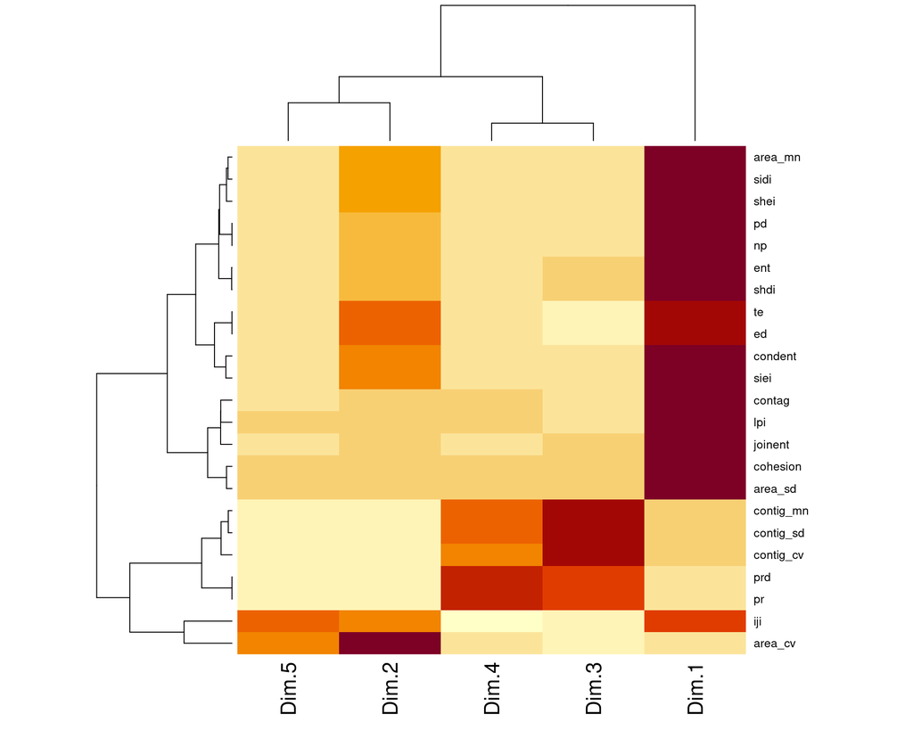

```r
poll_landuse_metrics_pca$var$cos2 %>% heatmap()
```

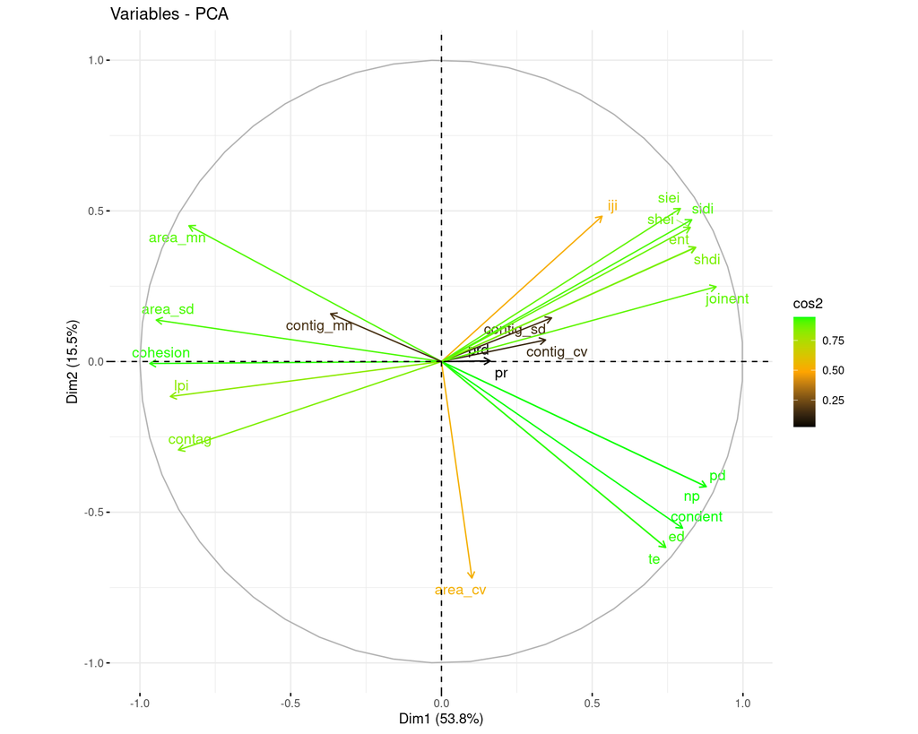

```r
fviz_pca_var(axes = c(1,2),
  poll_landuse_metrics_pca,
  col.var = "cos2",
  gradient.cols = c("black", "orange", "green"),
  repel = TRUE
  )
```

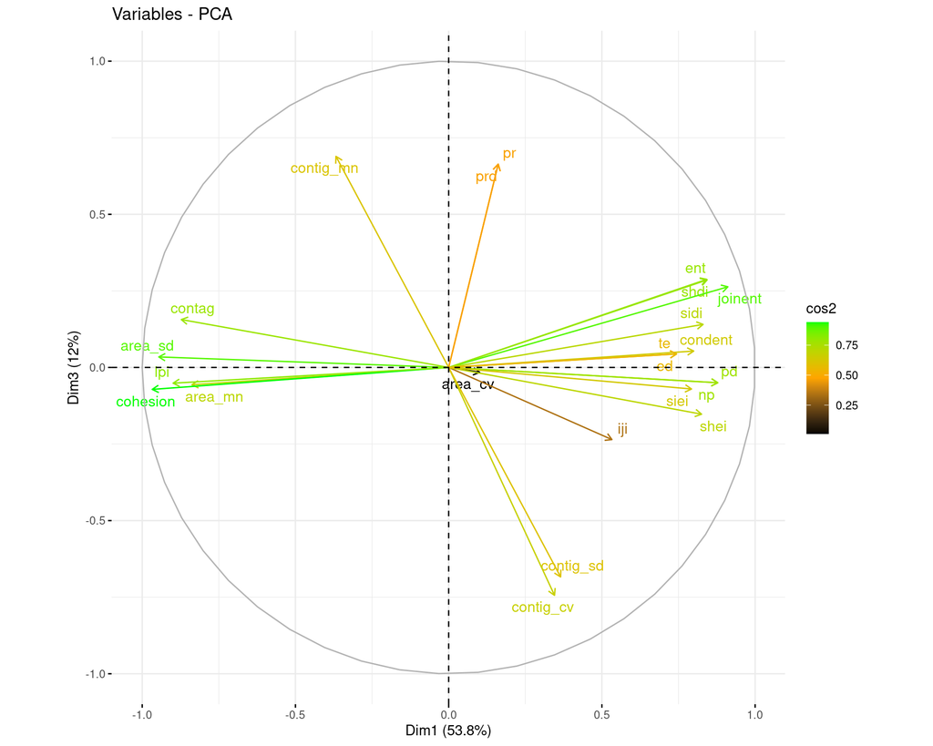

```r
fviz_pca_var(axes = c(1,3),
  poll_landuse_metrics_pca,
  col.var = "cos2",
  gradient.cols = c("black", "orange", "green"),
  repel = TRUE
  )
```

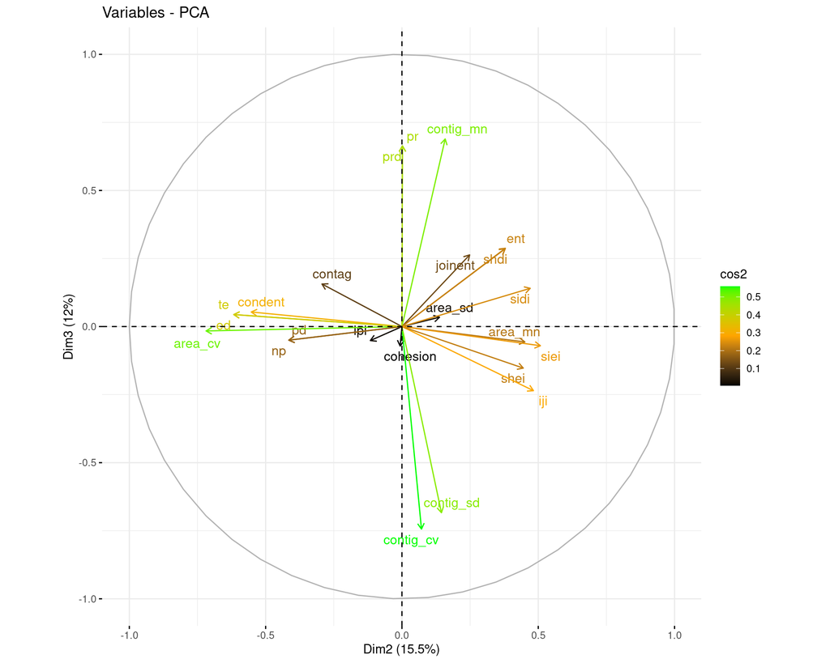

```r
fviz_pca_var(axes = c(2,3),
  poll_landuse_metrics_pca,
  col.var = "cos2",
  gradient.cols = c("black", "orange", "green"),
  repel = TRUE
  )
```

Dim1: - Most influenced by **cohesion, area_sd, lpi, contag, area_mn**, metrics which are highly correlated and whose values tend to decrease with landscape fragmentation; - Most influenced by **joinent, pd, np, sidi, shdi, ent**, metrics whose values tend to increase with fragmentation. - Related to landscape fragmentation;

Dim3: - Most influenced by **contig_mn, contig_cv and contig_sd**;

Check samples.

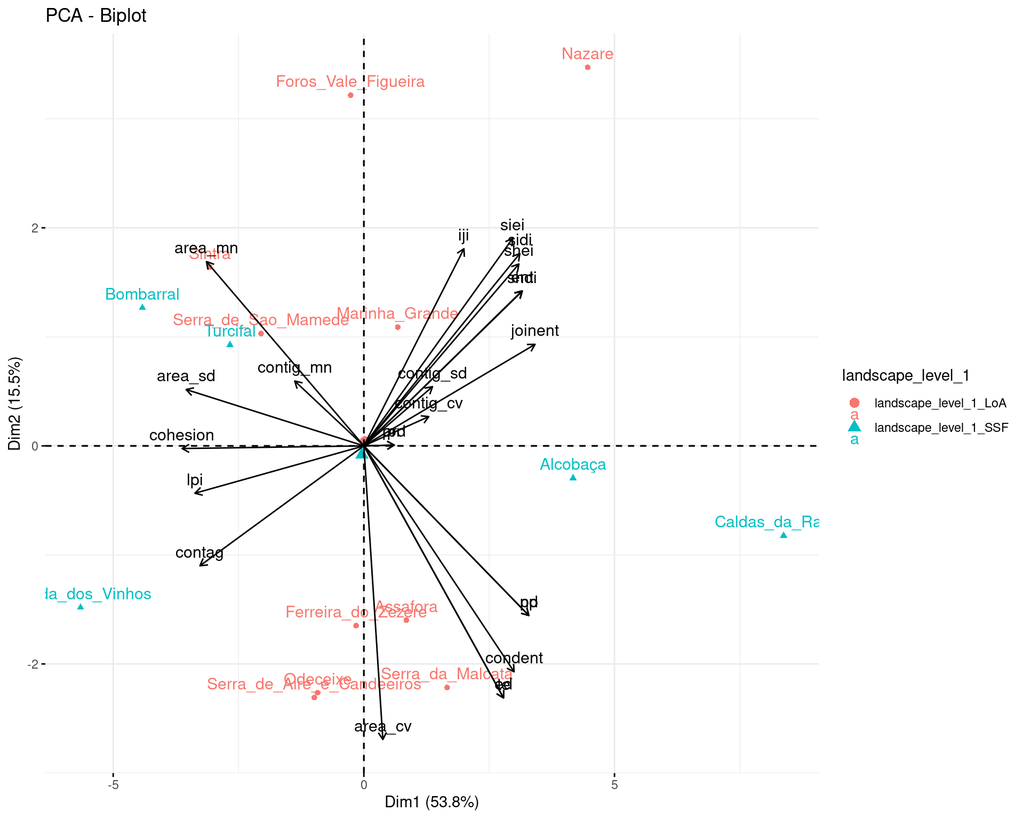

```r
fviz_pca_biplot(
  axes = c(1,2),
  poll_landuse_metrics_pca,
  label = "all",
  col.var = "black",
  habillage = 24
  )
```

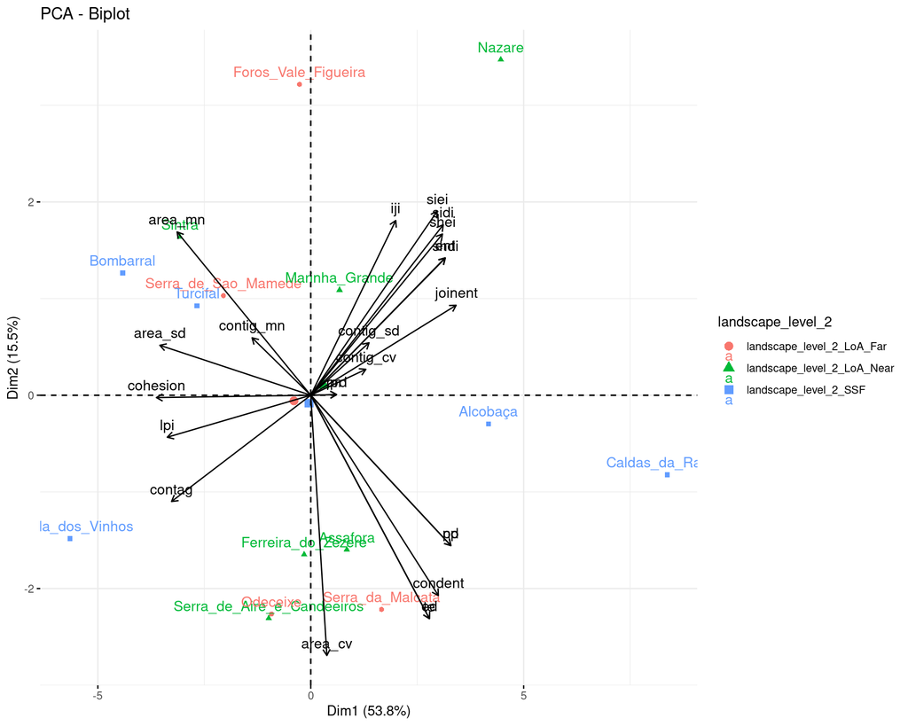

```r
fviz_pca_biplot(
  axes = c(1,2),
  poll_landuse_metrics_pca,
  label = "all",
  col.var = "black",
  habillage = 25
  )
```